# Childhood Adversity and Stressful Life Events as Risk Factors for Late Life Cognitive Impairment

Katrina Bazemore

BMIN 5030 Final Project, Fall 2022

# 1 Overview

Cognitive resilience has been theorized to explain variation in cognitive function between individuals with the same level of dementia pathology, with higher cognitive resilience delaying onset of dementia symptoms. Cognitive resilience is difficult to measure, with level of education and cognitive activity functioning as key proxies. Other experiences, such as childhood adversity and stressful events in later life have been associated with worse physical and mental health and may decrease the positive effects of education and cognitive activity. Using data from the RUSH Religious Orders Study Memory and Aging Project, which I learned about from Dr. Adam Naj (Assistant Professor of Epidemiology, DBEI), I will investigate the association between childhood adversity / later life stressful events and diagnosis of cognitive impairment. The Memory and Aging Project sub study enrolled over 2,000 older adults with no cognitive impairment at enrollment and conducted yearly follow up until mortality. Approaches to prepare the data and conduct analyses are informed by Dr. Blanca Himes (Assistant Professor of Informatics, DBEI).

> [https://github.com/KSBazemore/BMIN503_Final_Project]

# 2 Introduction

An estimated 6.5 million people in the United States have Alzheimer’s Disease (AD) in 2022. Women and racial minorities are disproportionately affected by AD and other dementias. This condition presents a substantial public health, economic, and emotional burden for those affected and their communities and is among the leading causes of death in older adults (1-3). Treatments for AD and dementia are limited, though delay in disease onset through reduction and control of risk factors has the potential to reduce prevalence of these conditions (4). One actionable way to delay disease onset may be through improvement of cognitive resilience. Many older adults do not exhibit clinical symptoms of dementia, despite substantial pathology (5). Cognitive resilience is thought to explain variations in functioning between those with similar levels of pathology, with greater resilience protecting against cognitive decline (6). Measures of cognitive resilience have been associated with reduced susceptibility to cognitive insults, including dementia and traumatic brain injury (7, 8). Results from the Adult Changes in Thought study showed adults with a college education had two times the odds of being classified as resilient based on comparisons of cognitive function prior to death, and pathology determined at autopsy (9). However, cognitive resilience is difficult to measure and define in life with key proxies including education level and participation in mentally engaging activities in later life (10, 11).

In contrast, negative life experiences such as depression and affective loss have been associated with earlier age of AD onset (12). Stressful life events, particularly early stressful life events have previously been associated with greater susceptibility to poor mental health (13). In mouse models, exposure to stress in early life was linked to decreased adult cognitive ability (14). This evidence suggests a possible relationship between early childhood / lifetime stressors and increased risk of dementia. I plan to explore the relationship between onset of cognitive impairment and childhood adversity / later life stressors. I hypothesize that among older adults at risk of cognitive impairment, those who have experienced greater childhood adversity or who are experiencing more stressful events in their later life will be at higher risk of developing cognitive impairment, independent of common measures of cognitive resilience.

# 3 Methods

## 3.1 Data Source

For this project I used data from the RUSH Religious Orders Study Memory and Aging Project. This is a prospective cohort study that enrolled older adults beginning in 1997 from retirement communities and senior housing in Chicago and Northeastern Illinois who had no signs of dementia or cognitive impairment at enrollment. This study focused on chronic conditions common in aging individuals with a special focus on cognitive decline. Participants agreed to yearly visits, which included collection of survey information, clinical assessments, bloodwork, and neuropsychological testing. Participants also agreed to organ donation for research after death. Available data includes demographic, life course, medical diagnoses, cognitive function, and genotypes.

## 3.2 Methodological Approach

I used baseline and longitudinal follow up data to determine 5 year odds of incident cognitive impairment by experience with childhood adversity. No participants had cognitive impairment at the start of their follow up, so any cognitive impairment diagnosed is incident impairment. Childhood adversity is defined a summary measure of participant response to multiple domains including financial need during childhood, emotional neglect, and parental violence. A greater value in the summary measure and individual domains indicates greater / more frequent experience with adversity. Proxy variables related to cognitive resilience include respondent education, cognitive resources and activity across the lifespan (childhood, young adulthood, late adulthood, and total), and socioeconomic status in early life. Respondents were classed as having cognitive impairment if they had any diagnosis of mild cognitive impairment, Alzheimer’s Disease, or other dementia, and were classed as having no cognitive impairment if they did not receive any of those diagnoses by the 5th year of follow up. For subjects who were lost to follow up or were deceased prior to either the 5th year of follow up or experiencing the outcome, multiple imputation was used to determine their most likely outcome.

To determine the impact of stressful life events in later life on risk of cognitive impairment, I used longitudinal data. At each follow up visit, participants were asked if in the past year they experienced stressful events including divorce, hospitalization, loss of a close family member, and taking on substantial caregiving activities. Five years of available follow up data was used to estimate hazard of cognitive impairment over time including stressful events as a time dependent covariate. Since the effects of stressful life events may carry over from previous years, cumulative stressful events over time were used in modeling hazard ratios.

First, I will load in necessary libraries.

```r
#Loading in libraries
library(gtsummary)
library(ggplot2)
library(ggdag)
library(dagitty)
library(ggplot2)
library(readxl)
library(table1)
library(cowplot)
library(dplyr)
library(gee)
library(mice)
library(howManyImputations)
library(survival)
library(ggsurvfit)
library(pROC)
library(stringr)
```

I use a directed acyclic graph (DAG) to determine important covariates to control for in adjusted analyses. Variables are included in the DAG based on my conceptualization of the factors related to exposure (adversity / stressful life events) and outcome (cognitive impairment). GGDAG tools are used to determine the minimally sufficient set of covariates to include to reduce confounding of the exposure and outcome relationship.

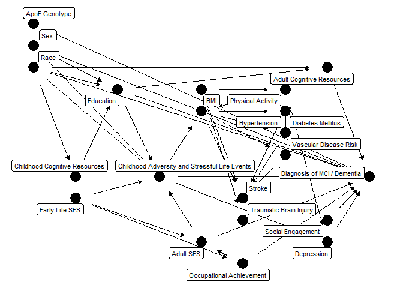

```r
#Conceptualization of variable relationships using ggdag
coord_dag <- list (
  x = c(ApoE = 0, sex = 0, race = 0, c_cog = 1, e_SES = 1, edu = 2, stress = 3, a_SES = 4, occ_ach = 5, age = 4, bmi = 4, stroke = 5, tbi = 5, p_act = 6, htn = 6, dm = 6, vasc = 6, depress = 7, a_cog = 7, dx = 8, soc = 7),
  y = c(ApoE = 11, sex = 10, race = 9, c_cog = 4, e_SES = 3, edu = 8, stress = 4, a_SES = 1, occ_ach = 0, age = 8, bmi = 7, stroke = 3, tbi = 2, p_act = 8, htn = 7, dm = 6, vasc = 5, depress = 1, a_cog = 9, dx = 4, soc = 2)
)
my_dag <- ggdag::dagify(dx ~ stress,
                        dx ~ a_cog,
                        dx ~ sex,
                        dx ~ race,
                        dx ~ ApoE,
                        dx ~ occ_ach,
                        dx ~ soc,
                        dx ~ depress,
                        dx ~ a_SES,
                        dx ~ edu, #10
                        stress ~ sex,
                        stress ~ race,
                        stress ~ e_SES,
                        stress ~ a_SES,
                        stress ~ edu, #15
                        c_cog ~ race,
                        c_cog ~ e_SES,
                        edu ~ sex,
                        edu ~ race,
                        edu ~ c_cog,
                        a_SES ~ e_SES,
                        a_SES ~ occ_ach,
                        bmi ~ stress,
                        bmi ~ age,
                        bmi ~ p_act,
                        stroke ~ bmi,
                        stroke ~ htn,
                        stroke ~ age,
                        stroke ~ dm,
                        stroke ~ vasc,
                        tbi ~ age,
                        occ_ach ~ e_SES,
                        p_act ~ age,
                        htn ~ p_act,
                        htn ~ bmi,
                        dm ~ bmi,
                        dm ~ p_act,
                        vasc ~ bmi,
                        vasc ~ p_act,
                        depress ~ stress,
                        depress ~ p_act,
                        a_cog ~ race,
                        a_cog ~ edu,
                        soc ~ depress,
                        exposure = 'stress',
                        outcome = 'dx',
                        labels = c('dx' = 'Diagnosis of MCI / Dementia', 'stress' = 'Childhood Adversity and Stressful Life Events', 'edu' = 'Education', 'a_cog' = 'Adult Cognitive Resources', 'sex' = 'Sex', 'race' = "Race", 'ApoE' = 'ApoE Genotype', 'occ_ach' = 'Occupational Achievement', 'soc' = 'Social Engagement', 'depress' = 'Depression', 'a_SES' = 'Adult SES', 'e_SES' = 'Early Life SES', 'c_cog' = 'Childhood Cognitive Resources', 'bmi' = 'BMI', 'p_act' = 'Physical Activity', 'stroke' = 'Stroke', 'htn' = 'Hypertension', 'dm' = 'Diabetes Mellitus', 'vasc' = 'Vascular Disease Risk', 'tbi' = 'Traumatic Brain Injury'), coords = coord_dag)

ggdag::ggdag(my_dag, text = FALSE, use_labels = "label", node_size = 6, text_size = 3) +
  expand_plot() +
  theme_void()
```

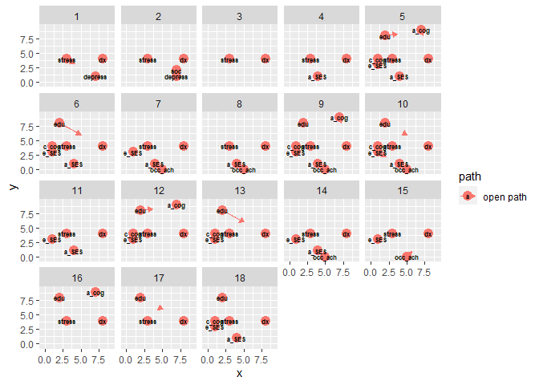

```r
#All the pathways between exposure and outcome
ggdag_paths(my_dag, text_col = 'black', text_size = 2, node_size = 4)
```

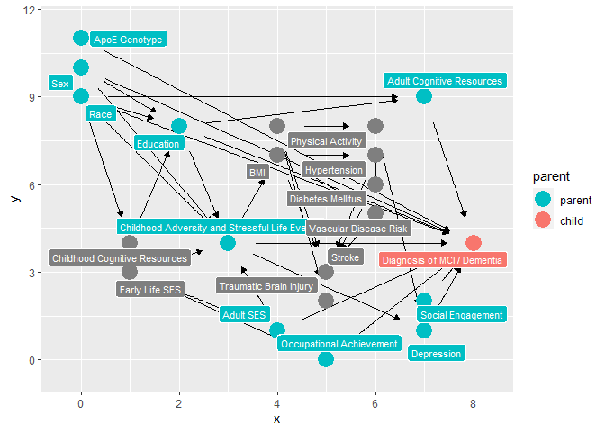

```r
#Highlighting the direct parents of dx
ggdag_parents(my_dag, 'dx', text = FALSE, use_labels = "label", node_size = 6, text_size = 3)
```

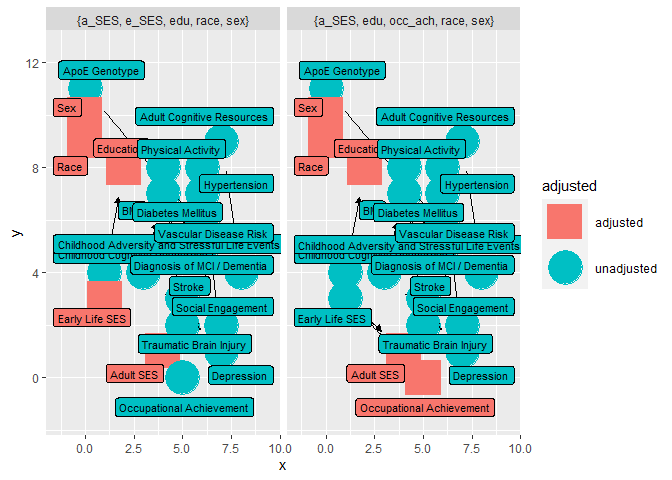

```r
#Options of minimum set needed to control for confounding
ggdag_adjustment_set(my_dag, text_col = 'black', text = FALSE, use_labels = "label", text_size = 3, node_size = 12)
```

The minimum set of covariates needed to control for confounding based on this DAG are either sex, race, education, early life SES, and adult SES or sex, race, education, adult SES, and occupational achievement. Since occupational achievement is not measured in the data available, I will use the first set of covariates in my adjusted models.

Next I will read in the data shared by RUSH.

```r
#File with repeated measures across follow up
lmap <- read_excel("dataset_1205_long_11-09-2022.xlsx",
    col_types = c("text", "text", "numeric",
        "text", "numeric", "numeric", "numeric",
        "numeric", "numeric", "numeric",
        "numeric", "numeric", "numeric",
        "numeric", "numeric", "numeric",
        "numeric", "numeric", "numeric",
        "numeric", "numeric", "numeric",
        "numeric"))

#File with constant measures across follow up
bmap <- read_excel("dataset_1205_basic_11-09-2022.xlsx")
```

Here I clean and rename variables in each of these datasets. I also create variables to simplify cognitive impairment diagnoses.

```r
#Data cleaning for constant variables
bmap <- dplyr::rename(bmap, id = projid, consensus_cogdx = cogdx, apoe = apoe_genotype, edu = educ, marital_bl = marital_now_bl, sex = msex, race = race7, ethnicity = spanish, c_cogA = chd_cogact_freq, life_cogA = lifetime_cogact_freq_bl, a_cogA = ma_adult_cogact_freq, y_cogA = ya_adult_cogact_freq, c_cogR = cog_res_age12, a_cogR = cog_res_age40, t_cogR = tot_cog_res, e_SES = early_hh_ses, sub_SES = ladder_composite, m_edu = mateduc, p_edu = pareduc, f_edu = pateduc) %>%
  mutate(apoe = factor(apoe, levels = c(22, 23,24, 33, 34, 44), labels = c('E2E2', 'E2E3', 'E2E4', 'E3E3', 'E3E4', 'E4E4'))) %>%
  mutate(consensus_cogdx = factor(consensus_cogdx, levels = c(1, 2, 3, 4, 5, 6), labels = c('NCI', 'MCI_no_external', 'MCI_external', 'AD_no_external', 'AD_external', 'Other Dementia'))) %>%
  mutate(consensus_simple = case_when(consensus_cogdx == 'NCI' ~ 'NCI', consensus_cogdx == 'MCI_no_external' | consensus_cogdx == 'MCI_external' ~ 'MCI', consensus_cogdx == 'AD_no_external' | consensus_cogdx == 'AD_external' ~ 'AD', consensus_cogdx == 'Other Dementia' ~ 'Dementia')) %>%
  mutate(marital_bl = factor(marital_bl, levels = c(1, 2, 3, 4, 5), labels = c('Never married', 'Married', 'Widowed', 'Divorced', 'Separated'))) %>%
  mutate(sex = factor(sex, levels = c(0, 1), labels = c('Female', 'Male'))) %>%
  mutate(race = factor(race, levels = c(1, 2, 3, 4, 5, 6, 7), labels = c('White', 'Black or african american', 'American indian / Alaska native', 'Native hawaiian / pacific islander', 'Asian', 'Other', 'Unknown'))) %>%
  mutate(ethnicity = factor(ethnicity, levels = c(1, 2), labels = c('Hispanic', 'Not hispanic'))) %>%
  mutate(q40inc = factor(q40inc, levels = c(1, 2, 3, 4, 5, 6, 7, 8, 9, 10), labels = c('0-4,999', '5,000-9,999', '10,000 - 14,999', '15,000 - 19,999', '20,000 - 24,999', '25,000 - 29,999', '30,000 - 34,999', '35,000 - 49,999', '50,000 - 74,999', '75,000+'))) %>%
  mutate(income_bl = factor(income_bl, levels = c(1, 2, 3, 4, 5, 6, 7, 8, 9, 10), labels = c('0-4,999', '5,000-9,999', '10,000 - 14,999', '15,000 - 19,999', '20,000 - 24,999', '25,000 - 29,999', '30,000 - 34,999', '35,000 - 49,999', '50,000 - 74,999', '75,000+')))

#Data cleaning for longitudinal set
lmap <- dplyr::rename(lmap, id = projid, dx_cog = dcfdx, park = r_pd, age_vist = age_at_visit, depress = r_depres, late_cogA = late_life_cogact_freq, p_act = phys5itemsum, discrim = discrim_cnt, late_soc = late_life_soc_act, isolation = social_isolation, support = social_support, htn = hypertension_cum, dm = dm_cum, stroke = stroke_cum, vasc_burden = vasc_4dis_sum, vasc_risk = vasc_risks_sum, neg_events = neglifeevents,) %>%
  mutate(dx_cog = factor(dx_cog, levels = c(1, 2, 3, 4, 5, 6) , labels = c('NCI', 'MCI_no_external', 'MCI_external', 'AD_no_external', 'AD_external', 'Other Dementia'))) %>%
   mutate(dx_sum = case_when(dx_cog == 'NCI' ~ 'NCI', dx_cog == 'MCI_no_external' | dx_cog == 'MCI_external' ~ 'MCI', dx_cog == 'AD_no_external' | dx_cog == 'AD_external' ~ 'AD', dx_cog == 'Other Dementia' ~ 'Dementia')) %>%
  mutate(simp_cogdx = case_when(dx_cog == 'NCI' ~ 0, TRUE ~ 1)) %>%
  mutate(park = factor(park, levels = c(1, 2, 3, 4), labels = c('Highly Probably', 'Probable', 'Possible', 'Not Present'))) %>%
  mutate(depress = factor(depress, levels = c(1, 2, 3, 4), labels = c('Highly probable', 'Probable', 'Possible', 'Not present'))) %>%
  mutate(htn = factor(htn, levels = c(0, 1), labels = c('No history of HTN', 'History of HTN'))) %>%
  mutate(dm = factor(dm, levels = c(0, 1), labels = c('No history of diabetes', 'History of diabetes'))) %>%
  mutate(stroke = factor(stroke, levels = c(0, 1), labels = c('No history of stroke', 'History of stroke')))
```

Looking roughly at missing responses and number of subjects followed at each follow up visit.

```r
#Missing in baseline
colSums(is.na(bmap))
```

```
##                    id                 study     emotional_neglect
##                     0                     0                   398
##        family_pro_sep        financial_need parental_intimidation
##                   400                   390                   395
##     parental_violence       tot_adverse_exp                  apoe
##                   395                   105                   432
##       age_first_ad_dx       consensus_cogdx                age_bl
##                  1715                   988                     0
##             age_death                   edu            marital_bl
##                   986                     0                   219
##                   sex                  race             ethnicity
##                     0                     0                     0
##                c_cogA             life_cogA                a_cogA
##                   138                   128                   130
##                y_cogA                c_cogR                a_cogR
##                   132                   136                   126
##                t_cogR                 e_SES             income_bl
##                   139                    43                   275
##               sub_SES                 m_edu                 p_edu
##                  1017                    59                    42
##                 f_edu                q40inc      consensus_simple
##                    92                   349                   988
```

```r
colSums(is.na(lmap))
```

```
##          id       study     fu_year   scaled_to  neg_events      dx_cog
##           0           0           0           0       10392         370
##        park cogn_global    age_vist     depress   late_cogA         bmi
##        2664         579         109         547        1017        2508
##       p_act     discrim    late_soc     soc_net   isolation     support
##         591       13895        1008        1035        1745        1715
##         htn          dm      stroke vasc_burden   vasc_risk      dx_sum
##         314         156         387         314         156         370
##  simp_cogdx
##           0
```

```r
#Looking at number of subjects present at each follow up visit
table(lmap$fu_year)
```

```
##
##    0    1    2    3    4    5    6    7    8    9   10   11   12   13   14   15
## 2249 1990 1790 1598 1435 1198 1063  915  781  653  539  434  343  270  203  172
##   16   17   18   19   20   21   22   23   24
##  137  104   67   48   16    9    1    5    1
```

There is a high degree of missing in variables related to childhood adversity and income at age 40 (~17%), additionally 19% of observations are missing ApoE genotype. Total childhood adverse experience has less missing that other measures of childhood adversity. Other measures with a high degree of missing will likely not impact my analysis such as age at death, and age at first AD diagnosis. These variables likely include as missing those who did not experience the specified event.

Merging the datasets so I have baseline information for each subject alongside longitudinal measures. I also create a status variable at each follow up point designating whether the respondent is enrolled, deceased, or lost to follow up before the next visit.

```r
#Merging the datasets
merge_map <- merge(bmap, lmap, by = c('id'))

#How many subjects are lost to follow up across visits
merge_map <- dplyr::mutate(merge_map, years_to_death = age_death-age_vist)

merge_map <- dplyr::mutate(merge_map, death_before_next_FU = case_when(years_to_death < 1.0 ~ 1, TRUE ~ 0))

#Creating a variable that specifies if this is the last visit for a specific subject
merge_map <- dplyr::mutate(merge_map, id_next = lead(id)) %>%
  mutate(last_visit = case_when(id != id_next ~ 1, TRUE ~ 0))

merge_map <- dplyr::mutate(merge_map, status = case_when(last_visit == 0 ~ 'enrolled', last_visit == 1 & death_before_next_FU == 1 ~ 'deceased', last_visit == 1 & death_before_next_FU == 0 ~ 'LTF'))

#Creating a detailed status variable - we are not worried about LTF if the subject experienced the outcome of interest (MCI/AD/Other Dementia)

#Creating a simplified variable for cognitive diagnosis
merge_map <- dplyr::mutate(merge_map, simple_cogdx = case_when(dx_cog == 'NCI' ~ 'Absent', TRUE ~ 'Present')) %>%
  mutate(simp_cogdx = case_when(dx_cog == 'NCI' ~ 0, TRUE ~ 1))


merge_map <- dplyr::mutate(merge_map, status_detail = case_when(status == 'enrolled' ~ simple_cogdx, status == 'deceased' & simple_cogdx == 'Absent' ~ 'dead_absent', status == 'deceased' & simple_cogdx == 'Present' ~ 'dead_present', status == 'LTF' & simple_cogdx == 'Present' ~ 'LTF_present', status == 'LTF' & simple_cogdx == 'Absent' ~ 'LTF_Absent'))

#Those who are deceased/LTF absent any cognitive impairment are missing outcome information
table(merge_map$status_detail, merge_map$fu_year)
```

```
##
##                   0    1    2    3    4    5    6    7    8    9   10   11   12
##   Absent       1449 1308 1167 1022  844  732  626  530  454  360  302  225  179
##   dead_absent    25   27   29   21   26   19   23   17   17   17    9    7    4
##   dead_present   39   45   48   41   45   55   49   48   44   41   31   28   27
##   LTF_Absent     89   54   62   66   92   45   44   38   30   39   34   30   24
##   LTF_present    53   46   42   46   75   29   45   35   33   22   39   35   30
##   Present       594  510  442  402  353  318  276  247  203  174  124  109   79
##
##                  13   14   15   16   17   18   19   20   21   22   23   24
##   Absent        140  117   98   68   44   29   10    5    2    0    0    0
##   dead_absent    10    4    3    6    1    0    3    0    0    0    0    0
##   dead_present   24   13   10    8    8    7    6    2    1    1    4    0
##   LTF_Absent     26   11   10   11   12    8    9    3    1    0    0    0
##   LTF_present    14    9   12    3   19   11   14    2    2    0    0    1
##   Present        56   49   39   41   20   12    6    4    3    0    1    0
```

I am interested in the 5 year odds of MCI/AD/Dementia, so I need to filter out the follow up visits occurring past year 5. Focusing on follow up through year 5 also reduces the amount of missing outcomes due to respondent death or loss to follow up over the 24 years of follow up included in this data. I determine respondent cognitive outcome by cognitive impairment diagnosis at the fifth year of follow up. If the respondent did not have 5 years of follow up their outcome was either impairment or missing depending on whether they had a cognitive impairment diagnosis before year 5 prior to loss to follow up or mortality.

```r
map5 <- dplyr::filter(merge_map, fu_year < 6)

#Extracting the year 5 outcome or last outcome per respondent, whichever comes first
disp5 <-  group_by(map5, id) %>%
  slice(c(which.max(fu_year))) %>%
  select(id, status, status_detail, simple_cogdx, dx_cog, dx_sum, simp_cogdx, fu_year)

#Status variable at 5 year visit: including missing category for those w/o impairment and w/o 5 year follow up
disp5 <- dplyr::mutate(disp5, enroll5 = case_when(fu_year < 5 ~ '0', TRUE ~ '1')) %>%
  mutate(simp_cogdx = as.character(simp_cogdx))

disp5 <- dplyr::mutate(disp5, yr_5_impairment = case_when(enroll5 == '1' & simp_cogdx == '1' ~ '1', enroll5 == '1' & simp_cogdx == '0' ~ '0', enroll5 == '0' & simp_cogdx == '1' ~ '1', enroll5 == '0' & simp_cogdx == '0' ~ NA_character_)) %>%
  mutate(yr_5_cognitive_dx = case_when(enroll5 == '1' ~ dx_sum, enroll5 == '0' & simp_cogdx == '1' ~ dx_sum, enroll5 == '0' & simp_cogdx == '0' ~ NA_character_))
```

Merging 5 year outcome information with the baseline file.

```r
#merging outcomes at last visit with bmap file
bmap_out <- dplyr::left_join(bmap, disp5, by = 'id')
```

Using the mice package for multiple imputation to address problems with missing data. I use the ‘How Many Imputations’ package to determine the number of imputations necessary to achieve stable standard errors.

```r
#Determining percent missing across the data
p_missing <- unlist(lapply(bmap_out, function(x) sum(is.na(x))))/nrow(bmap_out)
sort(p_missing[p_missing >0], decreasing = TRUE)
```

```
##       age_first_ad_dx               sub_SES       consensus_cogdx
##            0.76256114            0.45220098            0.43930636
##      consensus_simple             age_death     yr_5_cognitive_dx
##            0.43930636            0.43841707            0.28546020
##       yr_5_impairment                  apoe        family_pro_sep
##            0.24232992            0.19208537            0.17785683
##     emotional_neglect parental_intimidation     parental_violence
##            0.17696754            0.17563361            0.17563361
##        financial_need                q40inc             income_bl
##            0.17341040            0.15518008            0.12227657
##            marital_bl                t_cogR                c_cogA
##            0.09737661            0.06180525            0.06136060
##                c_cogR                y_cogA                a_cogA
##            0.06047132            0.05869275            0.05780347
##             life_cogA                a_cogR       tot_adverse_exp
##            0.05691418            0.05602490            0.04668742
##                dx_cog                dx_sum                 f_edu
##            0.04313028            0.04313028            0.04090707
##                 m_edu                 e_SES                 p_edu
##            0.02623388            0.01911961            0.01867497
```

```r
#Removing variables with percent missing greater than 30% from the dataset, those collinear with the variable of interest, and those I created
mice:::find.collinear(bmap_out)
```

```
## [1] "simp_cogdx"        "yr_5_impairment"   "yr_5_cognitive_dx"
```

```r
bmap_imp <- dplyr::select(bmap_out, -c(age_first_ad_dx, sub_SES, consensus_cogdx, consensus_simple, age_death, simp_cogdx, yr_5_cognitive_dx, simple_cogdx, dx_sum, dx_cog, enroll5, status, status_detail)) %>% mutate(yr_5_impairment = as.factor(yr_5_impairment))

label(bmap_imp$tot_adverse_exp) <- "Total Childhood Adversity"
label(bmap_imp$life_cogA) <- "Lifetime Cognitive Activity"
label(bmap_imp$income_bl) <- "Income at Enrollment"
label(bmap_imp$a_cogR) <- "Adult Cognitive Resources"

#Viewing mice-specified distributions for variables to be imputed
imp <- mice(bmap_imp, maxit=0)
predM <- imp$predictorMatrix
meth <-imp$method

#Determining how many imputations to run
set.seed(1234)
imp <- mice(bmap_imp, maxit = 3,
             predictorMatrix = predM,
             method = meth, print = FALSE)

fitimpA <- with(imp, glm(yr_5_impairment ~ tot_adverse_exp + q40inc + e_SES + edu + race + sex + life_cogA + a_cogR + income_bl + apoe, family = binomial()))

how_many_imputations(fitimpA)
```

```
## [1] 91
```

```r
#Multiple imputation based on needed number of imputations for stable standard errors
imp2 <- mice(bmap_imp, maxit = 91,
             predictorMatrix = predM,
             method = meth, print = FALSE)
```

Next I prepare a longitudinal dataframe for modeling with Cox Proportional Hazards. For this analysis I will consider those who died or were lost to follow up before experiencing the outcome as censored, though models accounting for competing risks may improve on estimates of cognitive impairment odds.

```r
#Limiting to 5-years of follow up
merge_map <- dplyr::filter(merge_map, fu_year < 6)

#Need to code an outcome/status variable NCI, CI, deceased/LTF
merge_map <- dplyr::mutate(merge_map, status2 = case_when(status == 'enrolled' ~ 1, status != 'enrolled' ~ 0)) %>%
                           mutate(outcome = case_when(status2 == 1 & simp_cogdx == 1 ~ 1, status2 == 1 & simp_cogdx == 0 ~ 0, TRUE ~ 2))

merge_map$outcome <- as.factor(merge_map$outcome)

#Outcome with only 2 levels (mortality as censored)
merge_map <- dplyr::mutate(merge_map, outcome2 = case_when(outcome == 0 ~ 0, outcome == 1 ~ 1, outcome ==2 ~ 0))

#Creating an end time variable
merge_map <- dplyr::mutate(merge_map, time2 = fu_year + 1)

#Creating cumulative summary of negative life events by respondent id
merge_map <- dplyr::mutate(merge_map, neg = case_when(neg_events >= 1 ~ neg_events, TRUE ~ 0))

merge_map <- merge_map %>%
  group_by(id) %>% mutate(cum_events = cumsum(neg))

merge_map <- ungroup(merge_map)
```

# 4 Results

## 4.1 Summary Statistics

```r
#Descriptive Summary of Constant Characteristics

#Table 1
label(bmap_out$apoe) <- "ApoE Genotype"
label(bmap_out$age_bl) <- "Age at Enrollment"
label(bmap_out$edu) <- "Years of Education"
label(bmap_out$marital_bl) <- "Marital Status at Enrollment"
label(bmap_out$sex) <- "Sex"
label(bmap_out$race) <- "Race"
label(bmap_out$ethnicity) <- "Ethnicity"
label(bmap_out$consensus_simple) <- "Cognitive Diagnosis at Death"
label(bmap_out$yr_5_cognitive_dx) <- "Cognitive Diagnosis at 5 Years"
label(bmap_out$age_death) <- "Age at Death"

bmap_out$yr_5_impairment <- factor(bmap_out$yr_5_impairment, levels = c(0,1), labels = c("Absent", "Present"))

table1(~apoe + age_bl + age_death + edu + marital_bl + sex + race + ethnicity + consensus_simple + yr_5_cognitive_dx | yr_5_impairment, data = bmap_out, overall = "Total", caption = "Demographic and Baseline Characteristics by 5 Year Cognitive Impairment")
```

Demographic and Baseline Characteristics by 5 Year Cognitive Impairment

|  | Absent (N=796) | Present (N=908) | Total (N=2249) |
| --- | --- | --- | --- |
| ApoE Genotype |  |  |  |
| E2E2 | 5 (0.6%) | 5 (0.6%) | 12 (0.5%) |
| E2E3 | 125 (15.7%) | 66 (7.3%) | 234 (10.4%) |
| E2E4 | 15 (1.9%) | 18 (2.0%) | 41 (1.8%) |
| E3E3 | 493 (61.9%) | 445 (49.0%) | 1134 (50.4%) |
| E3E4 | 121 (15.2%) | 189 (20.8%) | 363 (16.1%) |
| E4E4 | 9 (1.1%) | 21 (2.3%) | 33 (1.5%) |
| Missing | 28 (3.5%) | 164 (18.1%) | 432 (19.2%) |
| Age at Enrollment |  |  |  |
| Mean (SD) | 77.3 (7.17) | 83.1 (6.54) | 80.0 (7.57) |
| Median [Min, Max] | 78.2 [54.3, 95.9] | 83.7 [61.5, 100] | 80.7 [53.3, 100] |
| Age at Death |  |  |  |
| Mean (SD) | 92.0 (6.10) | 90.2 (6.08) | 90.1 (6.42) |
| Median [Min, Max] | 92.4 [69.3, 108] | 90.9 [65.9, 106] | 90.7 [65.9, 108] |
| Missing | 396 (49.7%) | 266 (29.3%) | 986 (43.8%) |
| Years of Education |  |  |  |
| Mean (SD) | 15.1 (3.16) | 14.8 (3.33) | 14.9 (3.34) |
| Median [Min, Max] | 15.0 [3.00, 28.0] | 15.0 [0, 30.0] | 15.0 [0, 30.0] |
| Marital Status at Enrollment |  |  |  |
| Never married | 50 (6.3%) | 46 (5.1%) | 136 (6.0%) |
| Married | 303 (38.1%) | 289 (31.8%) | 812 (36.1%) |
| Widowed | 271 (34.0%) | 384 (42.3%) | 842 (37.4%) |
| Divorced | 83 (10.4%) | 86 (9.5%) | 234 (10.4%) |
| Separated | 1 (0.1%) | 3 (0.3%) | 6 (0.3%) |
| Missing | 88 (11.1%) | 100 (11.0%) | 219 (9.7%) |
| Sex |  |  |  |
| Female | 619 (77.8%) | 626 (68.9%) | 1649 (73.3%) |
| Male | 177 (22.2%) | 282 (31.1%) | 600 (26.7%) |
| Race |  |  |  |
| White | 749 (94.1%) | 847 (93.3%) | 2102 (93.5%) |
| Black or african american | 38 (4.8%) | 49 (5.4%) | 115 (5.1%) |
| American indian / Alaska native | 3 (0.4%) | 2 (0.2%) | 8 (0.4%) |
| Native hawaiian / pacific islander | 1 (0.1%) | 0 (0%) | 1 (0.0%) |
| Asian | 3 (0.4%) | 6 (0.7%) | 12 (0.5%) |
| Other | 0 (0%) | 1 (0.1%) | 3 (0.1%) |
| Unknown | 2 (0.3%) | 3 (0.3%) | 8 (0.4%) |
| Ethnicity |  |  |  |
| Hispanic | 41 (5.2%) | 35 (3.9%) | 119 (5.3%) |
| Not hispanic | 755 (94.8%) | 873 (96.1%) | 2130 (94.7%) |
| Cognitive Diagnosis at Death |  |  |  |
| AD | 94 (11.8%) | 393 (43.3%) | 492 (21.9%) |
| Dementia | 7 (0.9%) | 9 (1.0%) | 16 (0.7%) |
| MCI | 82 (10.3%) | 207 (22.8%) | 308 (13.7%) |
| NCI | 216 (27.1%) | 32 (3.5%) | 445 (19.8%) |
| Missing | 397 (49.9%) | 267 (29.4%) | 988 (43.9%) |
| Cognitive Diagnosis at 5 Years |  |  |  |
| NCI | 796 (100%) | 0 (0%) | 796 (35.4%) |
| AD | 0 (0%) | 312 (34.4%) | 312 (13.9%) |
| Dementia | 0 (0%) | 17 (1.9%) | 17 (0.8%) |
| MCI | 0 (0%) | 482 (53.1%) | 482 (21.4%) |
| Missing | 0 (0%) | 97 (10.7%) | 642 (28.5%) |

The demographic table shows that those who experienced incident cognitive impairment within 5 years of enrollment were older at the time of enrollment, were more often male and widowed and had the ApoE E4 allele, as compared to those who did not have incident CI within 5 years.

```r
#Variables related to cognitive resilience
label(bmap_out$c_cogA) <- "Childhood Cognitive Activity"
label(bmap_out$life_cogA) <- "Lifetime Cognitive Activity"
label(bmap_out$y_cogA) <- "Young Adult Cognitive Activity"
label(bmap_out$c_cogR) <- "Childhood Cognitive Resources"
label(bmap_out$a_cogR) <- "Adult Cognitive Resources"
label(bmap_out$t_cogR) <- "Lifetime Cognitive Resources"
label(bmap_out$e_SES) <- "Early Life Socio-Economic Status"
label(bmap_out$income_bl) <- "Income at Enrollment"
label(bmap_out$m_edu) <- "Mother's Years of Education"
label(bmap_out$f_edu) <- "Father's Years of Education"
label(bmap_out$p_edu) <- "Combined Parental Years of Education"
label(bmap_out$q40inc) <- "Income at Age 40"
label(bmap_out$edu) <- "Years of Education"
label(bmap_out$a_cogA) <- "Adult Cognitive Activity"

bmap_out %>% dplyr::select(yr_5_impairment, edu, c_cogA, life_cogA, a_cogA, y_cogA, c_cogR:t_cogR, e_SES, income_bl, m_edu, f_edu, p_edu, q40inc) %>%
  gtsummary::tbl_summary(by = yr_5_impairment, statistic = list(all_continuous() ~ "{mean} ({sd})", all_categorical() ~ "{n}, / {N} ({p}%)"), digits = all_continuous() ~ 2, missing_text = "Missing") %>%
  modify_caption("**Cognitive Resilience Characteristics by 5 Year Cognitive Impairment**") %>%
  add_overall() %>%
  bold_labels() %>%
  add_p()
```

**Cognitive Resilience Characteristics by 5 Year Cognitive Impairment**

| **Characteristic** | **Overall**, N = 1,704<sup>1</sup> | **Absent**, N = 796<sup>1</sup> | **Present**, N = 908<sup>1</sup> | **p-value**<sup>2</sup> |
| --- | --- | --- | --- | --- |
| Years of Education | 14.96 (3.25) | 15.09 (3.16) | 14.85 (3.33) | 0.12 |
| Childhood Cognitive Activity | 3.00 (0.68) | 3.03 (0.67) | 2.96 (0.70) | 0.047 |
| Missing | 114 | 34 | 80 |  |
| Lifetime Cognitive Activity | 3.11 (0.55) | 3.17 (0.54) | 3.05 (0.55) | <0.001 |
| Missing | 106 | 34 | 72 |  |
| Adult Cognitive Activity | 3.27 (0.65) | 3.34 (0.63) | 3.21 (0.67) | <0.001 |
| Missing | 108 | 33 | 75 |  |
| Young Adult Cognitive Activity | 3.06 (0.68) | 3.11 (0.67) | 3.01 (0.68) | 0.001 |
| Missing | 111 | 34 | 77 |  |
| Childhood Cognitive Resources | 4.27 (2.08) | 4.33 (2.00) | 4.21 (2.15) | 0.3 |
| Missing | 113 | 37 | 76 |  |
| Adult Cognitive Resources | 5.93 (1.66) | 6.11 (1.55) | 5.78 (1.74) | <0.001 |
| Missing | 104 | 33 | 71 |  |
| Lifetime Cognitive Resources | 10.20 (3.16) | 10.44 (2.94) | 9.99 (3.34) | 0.030 |
| Missing | 116 | 36 | 80 |  |
| Early Life Socio-Economic Status | -0.01 (0.76) | 0.04 (0.73) | -0.06 (0.78) | 0.025 |
| Missing | 38 | 8 | 30 |  |
| Income at Enrollment |  |  |  | 0.008 |
| 0-4,999 | 37, / 1,493 (2.5%) | 8, / 757 (1.1%) | 29, / 736 (3.9%) |  |
| 5,000-9,999 | 50, / 1,493 (3.3%) | 21, / 757 (2.8%) | 29, / 736 (3.9%) |  |
| 10,000 - 14,999 | 92, / 1,493 (6.2%) | 39, / 757 (5.2%) | 53, / 736 (7.2%) |  |
| 15,000 - 19,999 | 122, / 1,493 (8.2%) | 61, / 757 (8.1%) | 61, / 736 (8.3%) |  |
| 20,000 - 24,999 | 125, / 1,493 (8.4%) | 66, / 757 (8.7%) | 59, / 736 (8.0%) |  |
| 25,000 - 29,999 | 123, / 1,493 (8.2%) | 64, / 757 (8.5%) | 59, / 736 (8.0%) |  |
| 30,000 - 34,999 | 148, / 1,493 (9.9%) | 74, / 757 (9.8%) | 74, / 736 (10%) |  |
| 35,000 - 49,999 | 256, / 1,493 (17%) | 148, / 757 (20%) | 108, / 736 (15%) |  |
| 50,000 - 74,999 | 262, / 1,493 (18%) | 132, / 757 (17%) | 130, / 736 (18%) |  |
| 75,000+ | 278, / 1,493 (19%) | 144, / 757 (19%) | 134, / 736 (18%) |  |
| Missing | 211 | 39 | 172 |  |
| Mother's Years of Education | 10.22 (3.84) | 10.48 (3.80) | 9.98 (3.87) | 0.046 |
| Missing | 53 | 11 | 42 |  |
| Father's Years of Education | 10.22 (4.51) | 10.46 (4.41) | 10.00 (4.59) | 0.092 |
| Missing | 77 | 25 | 52 |  |
| Combined Parental Years of Education | 10.19 (3.78) | 10.45 (3.65) | 9.96 (3.88) | 0.054 |
| Missing | 37 | 8 | 29 |  |
| Income at Age 40 |  |  |  | 0.9 |
| 0-4,999 | 56, / 1,435 (3.9%) | 25, / 735 (3.4%) | 31, / 700 (4.4%) |  |
| 5,000-9,999 | 98, / 1,435 (6.8%) | 43, / 735 (5.9%) | 55, / 700 (7.9%) |  |
| 10,000 - 14,999 | 134, / 1,435 (9.3%) | 68, / 735 (9.3%) | 66, / 700 (9.4%) |  |
| 15,000 - 19,999 | 139, / 1,435 (9.7%) | 72, / 735 (9.8%) | 67, / 700 (9.6%) |  |
| 20,000 - 24,999 | 174, / 1,435 (12%) | 93, / 735 (13%) | 81, / 700 (12%) |  |
| 25,000 - 29,999 | 156, / 1,435 (11%) | 86, / 735 (12%) | 70, / 700 (10%) |  |
| 30,000 - 34,999 | 164, / 1,435 (11%) | 84, / 735 (11%) | 80, / 700 (11%) |  |
| 35,000 - 49,999 | 253, / 1,435 (18%) | 133, / 735 (18%) | 120, / 700 (17%) |  |
| 50,000 - 74,999 | 176, / 1,435 (12%) | 89, / 735 (12%) | 87, / 700 (12%) |  |
| 75,000+ | 85, / 1,435 (5.9%) | 42, / 735 (5.7%) | 43, / 700 (6.1%) |  |
| Missing | 269 | 61 | 208 |  |

<sup>1</sup> Mean (SD); n, / N (%)  
<sup>2</sup> Wilcoxon rank sum test; Pearson's Chi-squared test

Among variables thought to contribute to cognitive resilience, cognitive activity across multiple periods, adult cognitive resources, and income at enrollment were most strongly associated with CI. In adjusted analyses I will use lifetime cognitive resilience alongside adult cognitive resources and income at enrollment.

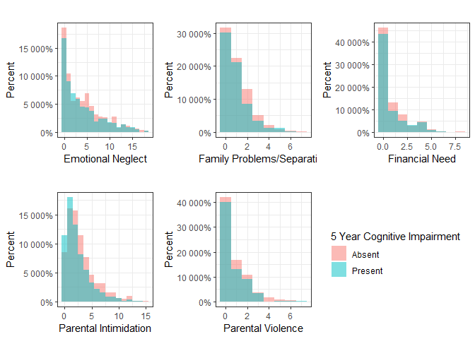

```r
#Descriptive of adverse experience vs outcome
emotional_neglect <- ggplot(data = subset(bmap_out, !is.na(yr_5_impairment)), aes(x = emotional_neglect, fill = yr_5_impairment)) +
  geom_histogram(position = "identity", binwidth=1, alpha = 0.5, show.legend = FALSE) +
  scale_y_continuous(labels = scales::percent) +
  labs(title = "                             ", x = "Emotional Neglect", y = "Percent", fill = "5 Year Cognitive Impairment") +
  theme_bw()

family_separation <- ggplot(data = subset(bmap_out, !is.na(yr_5_impairment)), aes(x = family_pro_sep, fill = yr_5_impairment)) +
  geom_histogram(position = "identity", binwidth=1, alpha = 0.5, show.legend = FALSE) +
  scale_y_continuous(labels = scales::percent) +
  labs(title = "                             ", x = "Family Problems/Separation", y = "Percent", fill = "5 Year Cognitive Impairment") +
  theme_bw()

financial_need <- ggplot(data = subset(bmap_out, !is.na(yr_5_impairment)), aes(x = financial_need, fill = yr_5_impairment)) +
  geom_histogram(position = "identity", binwidth=1, alpha = 0.5, show.legend = FALSE) +
  scale_y_continuous(labels = scales::percent) +
  labs(title = "                             ", x = "Financial Need", y = "Percent", fill = "5 Year Cognitive Impairment") +
  theme_bw()

intimidation <- ggplot(data = subset(bmap_out, !is.na(yr_5_impairment)), aes(x = parental_intimidation, fill = yr_5_impairment)) +
  geom_histogram(position = "identity", binwidth=1, alpha = 0.5, show.legend = FALSE) +
  scale_y_continuous(labels = scales::percent) +
  labs(title = "                              ", x = "Parental Intimidation", y = "Percent", fill = "5 Year Cognitive Impairment") +
  theme_bw()

p_violence <- ggplot(data = subset(bmap_out, !is.na(yr_5_impairment)), aes(x = parental_violence, fill = yr_5_impairment)) +
  geom_histogram(position = "identity", binwidth=1, alpha = 0.5) +
  scale_y_continuous(labels = scales::percent) +
  labs(title = "                                 ", x = "Parental Violence", y = "Percent", fill = "5 Year Cognitive Impairment") +
  theme_bw()

#pulling a legend from one plot
legend <- get_legend(p_violence)

#plotting childhood adversity in a grid
plot_grid(emotional_neglect, family_separation, financial_need, intimidation, p_violence + theme(legend.position = "none"), legend)
```

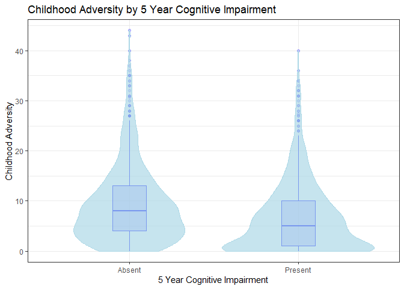

```r
#Box plot for summary measure of childhood adversity
ggplot(data = subset(bmap_out, !is.na(yr_5_impairment)), aes(yr_5_impairment, tot_adverse_exp)) +
    geom_boxplot(color = "blue", fill = "blue", alpha = 0.2, width = 0.2) +
    geom_violin(colour = "lightblue", fill = "lightblue", alpha = 0.7) +
  labs(title = "Childhood Adversity by 5 Year Cognitive Impairment", x = "5 Year Cognitive Impairment", y = "Childhood Adversity") +
  theme_bw()
```

The histograms and boxplots of experiences with childhood adversity suggest that those who experienced CI within 5 years had less childhood adversity than those who did not. This is contrary to my original hypothesis, but may be due to confounding.

Next I look at participant characteristics which might change over time.

```r
#Descriptive Summary of Longitudinal Characteristics
label(merge_map$htn) <- "Hypertension"
label(merge_map$depress) <- "Clinical Depression"
label(merge_map$dm) <- "Diabetes Mellitus"
label(merge_map$stroke) <- "Stroke"
label(merge_map$isolation) <- "Perceived social isolation"
label(merge_map$vasc_burden) <- "Vascular Disease Burden"
label(merge_map$support) <- "Perceived Social Support"
label(merge_map$vasc_risk) <- "Vascular Disease Risk Factors"
label(merge_map$apoe) <- "ApoE Genotype"

merge_map$outcome3 <- factor(merge_map$outcome2, levels = c(0,1), labels = c("Absent", "Present"))

table1(~htn + vasc_risk + vasc_burden + stroke + dm + isolation + support + depress | outcome3, data = merge_map, overall = "Total", caption = "Longitudinal Characteristics by Cognitive Impairment")
```

Longitudinal Characteristics by Cognitive Impairment

|  | Absent (N=7641) | Present (N=2619) | Total (N=10260) |
| --- | --- | --- | --- |
| Hypertension |  |  |  |
| No history of HTN | 3174 (41.5%) | 1130 (43.1%) | 4304 (41.9%) |
| History of HTN | 4397 (57.5%) | 1403 (53.6%) | 5800 (56.5%) |
| Missing | 70 (0.9%) | 86 (3.3%) | 156 (1.5%) |
| Vascular Disease Risk Factors |  |  |  |
| Mean (SD) | 1.15 (0.816) | 1.11 (0.821) | 1.14 (0.818) |
| Median [Min, Max] | 1.00 [0, 3.00] | 1.00 [0, 3.00] | 1.00 [0, 3.00] |
| Missing | 34 (0.4%) | 47 (1.8%) | 81 (0.8%) |
| Vascular Disease Burden |  |  |  |
| Mean (SD) | 0.371 (0.665) | 0.459 (0.720) | 0.393 (0.680) |
| Median [Min, Max] | 0 [0, 4.00] | 0 [0, 4.00] | 0 [0, 4.00] |
| Missing | 70 (0.9%) | 86 (3.3%) | 156 (1.5%) |
| Stroke |  |  |  |
| No history of stroke | 6707 (87.8%) | 2149 (82.1%) | 8856 (86.3%) |
| History of stroke | 710 (9.3%) | 360 (13.7%) | 1070 (10.4%) |
| Missing | 224 (2.9%) | 110 (4.2%) | 334 (3.3%) |
| Diabetes Mellitus |  |  |  |
| No history of diabetes | 6393 (83.7%) | 2212 (84.5%) | 8605 (83.9%) |
| History of diabetes | 1214 (15.9%) | 360 (13.7%) | 1574 (15.3%) |
| Missing | 34 (0.4%) | 47 (1.8%) | 81 (0.8%) |
| Perceived social isolation |  |  |  |
| Mean (SD) | 2.15 (0.638) | 2.38 (0.632) | 2.21 (0.644) |
| Median [Min, Max] | 2.00 [1.00, 5.00] | 2.20 [1.00, 5.00] | 2.00 [1.00, 5.00] |
| Missing | 674 (8.8%) | 421 (16.1%) | 1095 (10.7%) |
| Perceived Social Support |  |  |  |
| Mean (SD) | 4.40 (0.638) | 4.21 (0.700) | 4.35 (0.658) |
| Median [Min, Max] | 4.50 [1.00, 5.00] | 4.00 [1.00, 5.00] | 4.25 [1.00, 5.00] |
| Missing | 666 (8.7%) | 403 (15.4%) | 1069 (10.4%) |
| Clinical Depression |  |  |  |
| Highly probable | 60 (0.8%) | 30 (1.1%) | 90 (0.9%) |
| Probable | 147 (1.9%) | 58 (2.2%) | 205 (2.0%) |
| Possible | 297 (3.9%) | 113 (4.3%) | 410 (4.0%) |
| Not present | 7023 (91.9%) | 2308 (88.1%) | 9331 (90.9%) |
| Missing | 114 (1.5%) | 110 (4.2%) | 224 (2.2%) |

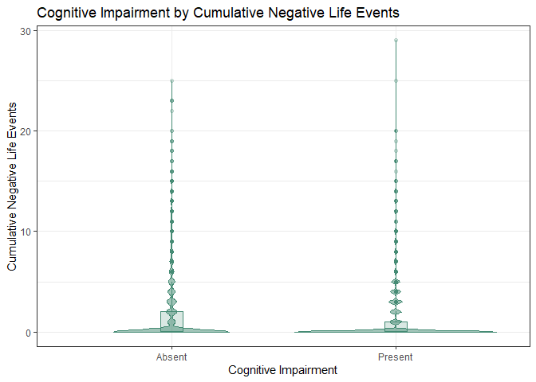

```r
ggplot(data = merge_map, aes(outcome3, cum_events)) +
  geom_boxplot(color = "aquamarine4", fill = "aquamarine4", alpha = 0.2, width = 0.1) +
  geom_violin(colour = "aquamarine4", fill = "aquamarine4", alpha = 0.5) +
  labs(title = "Cognitive Impairment by Cumulative Negative Life Events", x = "Cognitive Impairment", y = "Cumulative Negative Life Events") +
  theme_bw()
```

Having had a stroke appears to be more common in those who have CI by the end of follow up. Cumulative negative life events are higher in those who are absent CI at the end of follow up, which is again contrary to my hypothesis but may be explained by confounding.

## 4.2 Building Regression Models

Here, I build logistic regression models to estimate the 5 year odds of cognitive impairment. I construct an unadjusted model, a model adjusting for the covariates specified by the DAG, proxies for cognitive resilience, and ApoE genotype to improve precision of the estimate. Models with interaction terms between total childhood adversity and each of the three cognitive resilience variables are also run to determine if the protective effects of cognitive resilience are attenuated by experience with adversity.

```r
#Logistic regression for childhood adversity and any cognitive impairment

#Unadjusted logistic regression on the imputed set
fitimp <- with(imp, glm(yr_5_impairment ~ tot_adverse_exp, family = binomial()))

unadjust <- tbl_regression(fitimp, exponentiate = TRUE)

#Adjusted logistic regression on the imputed set
fitimpA <- with(imp, glm(yr_5_impairment ~ tot_adverse_exp + q40inc + e_SES + edu + race + sex + life_cogA + a_cogR + income_bl + apoe, family = binomial()))

adjust <- tbl_regression(fitimpA, exponentiate = TRUE, include = c(tot_adverse_exp, life_cogA, a_cogR, income_bl))

#Adjusted logistic regression on the imputed set testing interaction 1
fitimpB <- with(imp, glm(yr_5_impairment ~ tot_adverse_exp*life_cogA + q40inc + e_SES + edu + race + sex + a_cogR + income_bl + apoe, family = binomial()))

interact1 <- tbl_regression(fitimpB, exponentiate = TRUE, include = c(-q40inc, -e_SES, -edu, -race, -sex, -a_cogR, -income_bl, -apoe))

#Adjusted logistic regression on the imputed set testing interaction 2
fitimpC <- with(imp, glm(yr_5_impairment ~ tot_adverse_exp*a_cogR + q40inc + e_SES + edu + race + sex + life_cogA + income_bl + apoe, family = binomial()))

interact2 <- tbl_regression(fitimpC, exponentiate = TRUE, include = c(-q40inc, -e_SES, -edu, -race, -sex, -life_cogA, -income_bl, -apoe))

#Adjusted logistic regression on the imputed set testing interaction 3
fitimpD <- with(imp, glm(yr_5_impairment ~ tot_adverse_exp*income_bl + q40inc + e_SES + edu + race + sex + life_cogA + a_cogR + apoe, family = binomial()))

interact3 <- tbl_regression(fitimpD, exponentiate = TRUE, include = c(-q40inc, -e_SES, -edu, -race, -sex, -life_cogA, -a_cogR, -apoe))

#Comparing Models
tbl_merge(list(unadjust, adjust, interact1, interact2, interact3), tab_spanner = (paste0(c("Unadjusted Model", "Adjusted Model*", "Interact: Lifetime Cognitive Activity*", "Interact: Adult Cognitive Resources*", "Interact: Income at Baseline*")))) %>%
  as_gt() %>%
  gt::tab_source_note(str_glue("*Adjusted for Income at age 40, early childhood SES, Education, Race, Sex, Lifetime Cognitive Activity, Adult Cognitive Resources, Income at Baseline, and ApoE Genotype"))
```

| **Characteristic** | Unadjusted Model **OR**<sup>1</sup> | Unadjusted Model **95% CI**<sup>1</sup> | Unadjusted Model **p-value** | Adjusted Model* **OR**<sup>1</sup> | Adjusted Model* **95% CI**<sup>1</sup> | Adjusted Model* **p-value** | Interact: Lifetime Cognitive Activity* **OR**<sup>1</sup> | Interact: Lifetime Cognitive Activity* **95% CI**<sup>1</sup> | Interact: Lifetime Cognitive Activity* **p-value** | Interact: Adult Cognitive Resources* **OR**<sup>1</sup> | Interact: Adult Cognitive Resources* **95% CI**<sup>1</sup> | Interact: Adult Cognitive Resources* **p-value** | Interact: Income at Baseline* **OR**<sup>1</sup> | Interact: Income at Baseline* **95% CI**<sup>1</sup> | Interact: Income at Baseline* **p-value** |
| --- | --- | --- | --- | --- | --- | --- | --- | --- | --- | --- | --- | --- | --- | --- | --- |
| Total Childhood Adversity | 0.96 | 0.95, 0.97 | <0.001 | 0.95 | 0.94, 0.97 | <0.001 | 0.95 | 0.90, 1.02 | 0.15 | 0.97 | 0.93, 1.01 | 0.14 | 0.96 | 0.88, 1.04 | 0.3 |
| Lifetime Cognitive Activity |  |  |  | 0.76 | 0.61, 0.93 | 0.010 | 0.76 | 0.57, 1.00 | 0.049 |  |  |  |  |  |  |
| Adult Cognitive Resources |  |  |  | 0.93 | 0.87, 0.99 | 0.031 |  |  |  | 0.95 | 0.87, 1.04 | 0.3 |  |  |  |
| Income at Enrollment |  |  |  |  |  |  |  |  |  |  |  |  |  |  |  |
| 0-4,999 |  |  |  | — | — |  |  |  |  |  |  |  | — | — |  |
| 5,000-9,999 |  |  |  | 0.72 | 0.26, 1.99 | 0.5 |  |  |  |  |  |  | 1.13 | 0.24, 5.35 | 0.9 |
| 10,000 - 14,999 |  |  |  | 0.59 | 0.22, 1.53 | 0.3 |  |  |  |  |  |  | 0.66 | 0.19, 2.31 | 0.5 |
| 15,000 - 19,999 |  |  |  | 0.38 | 0.15, 0.94 | 0.037 |  |  |  |  |  |  | 0.40 | 0.12, 1.31 | 0.13 |
| 20,000 - 24,999 |  |  |  | 0.33 | 0.13, 0.82 | 0.017 |  |  |  |  |  |  | 0.35 | 0.11, 1.14 | 0.081 |
| 25,000 - 29,999 |  |  |  | 0.34 | 0.13, 0.87 | 0.025 |  |  |  |  |  |  | 0.47 | 0.14, 1.62 | 0.2 |
| 30,000 - 34,999 |  |  |  | 0.40 | 0.16, 1.00 | 0.051 |  |  |  |  |  |  | 0.41 | 0.12, 1.41 | 0.2 |
| 35,000 - 49,999 |  |  |  | 0.31 | 0.13, 0.75 | 0.009 |  |  |  |  |  |  | 0.32 | 0.10, 0.97 | 0.045 |
| 50,000 - 74,999 |  |  |  | 0.38 | 0.15, 0.97 | 0.043 |  |  |  |  |  |  | 0.38 | 0.12, 1.24 | 0.11 |
| 75,000+ |  |  |  | 0.44 | 0.17, 1.13 | 0.086 |  |  |  |  |  |  | 0.39 | 0.12, 1.24 | 0.11 |
| Total Childhood Adversity * Lifetime Cognitive Activity |  |  |  |  |  |  | 1.00 | 0.98, 1.02 | >0.9 |  |  |  |  |  |  |
| Total Childhood Adversity * Adult Cognitive Resources |  |  |  |  |  |  |  |  |  | 1.00 | 0.99, 1.00 | 0.4 |  |  |  |
| Total Childhood Adversity * Income at Enrollment |  |  |  |  |  |  |  |  |  |  |  |  |  |  |  |
| Total Childhood Adversity * 5,000-9,999 |  |  |  |  |  |  |  |  |  |  |  |  | 0.96 | 0.87, 1.07 | 0.5 |
| Total Childhood Adversity * 10,000 - 14,999 |  |  |  |  |  |  |  |  |  |  |  |  | 0.99 | 0.90, 1.08 | 0.8 |
| Total Childhood Adversity * 15,000 - 19,999 |  |  |  |  |  |  |  |  |  |  |  |  | 0.99 | 0.91, 1.09 | >0.9 |
| Total Childhood Adversity * 20,000 - 24,999 |  |  |  |  |  |  |  |  |  |  |  |  | 0.99 | 0.91, 1.08 | 0.9 |
| Total Childhood Adversity * 25,000 - 29,999 |  |  |  |  |  |  |  |  |  |  |  |  | 0.96 | 0.88, 1.06 | 0.5 |
| Total Childhood Adversity * 30,000 - 34,999 |  |  |  |  |  |  |  |  |  |  |  |  | 1.00 | 0.91, 1.09 | >0.9 |
| Total Childhood Adversity * 35,000 - 49,999 |  |  |  |  |  |  |  |  |  |  |  |  | 1.00 | 0.91, 1.09 | >0.9 |
| Total Childhood Adversity * 50,000 - 74,999 |  |  |  |  |  |  |  |  |  |  |  |  | 1.00 | 0.91, 1.09 | >0.9 |
| Total Childhood Adversity * 75,000+ |  |  |  |  |  |  |  |  |  |  |  |  | 1.02 | 0.93, 1.11 | 0.7 |

*Adjusted for Income at age 40, early childhood SES, Education, Race, Sex, Lifetime Cognitive Activity, Adult Cognitive Resources, Income at Baseline, and ApoE Genotype  
<sup>1</sup> OR = Odds Ratio, CI = Confidence Interval

In the unadjusted and adjusted models, total childhood adversity is significantly associated with a reduction in 5 year odds of cognitive impairment, as are the three cognitive resilience proxies. The individual interaction terms are not significant though inclusion of interaction terms does lead to an attenuation of both the effects of childhood adversity and cognitive resilience proxies towards the null.

I next consider the hazard of cognitive impairment over 5 years using survival methods.

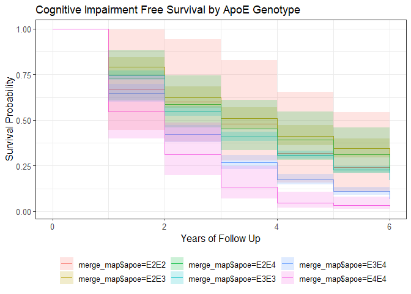

```r
#Kaplan Meier Curve: Cognitive Impairment Free survival
survfit(formula = (Surv(merge_map$fu_year, merge_map$time2, merge_map$outcome2) ~ merge_map$apoe)) %>%
  ggsurvfit() +
  labs(x = "Years of Follow Up", y = "Survival Probability", title = "Cognitive Impairment Free Survival by ApoE Genotype") +
  add_confidence_interval()
```

The Kaplan-Meier curve shows lower probability of cognitive impairment free survival in those carrying at least one ApoE E4 allele. While we only used 5 years of follow up data to construct this figure, a 6th year is show on this x-axis. This is because each repeated observation within a participant is identified with a start and stop point. The 6th year is the stop point for the 5th year of follow up.

Next, I run unadjusted Cox Proportional Hazards models and use k-fold cross validation to assess the model’s predictive ability.

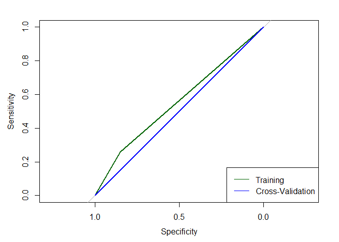

```r
#Unadjusted Survival
label(merge_map$cum_events) <- "Cumulative Stressful Events"

cfit <- coxph(Surv(fu_year, time2, outcome2) ~ cum_events, id = id, merge_map)
cph.pred <- predict(cfit, data = merge_map, type = 'risk')
cph.pred <- case_when(cph.pred <0.5 ~ 0, cph.pred >= 0.5 ~ 1)

Unadjust_cox <- tbl_regression(cfit, exponentiate = TRUE, include = c(cum_events))

#K-fold Cross Validation
N = nrow(merge_map)
K = 10
set.seed(1234)
s = sample(1:K, size = N, replace = T)
pred.outputs.cph <- vector(mode = "numeric", length = N)
obs.outputs <- vector(mode = "numeric", length = N)
offset <- 0
for (i in 1:K) {
  train <- filter(merge_map, s !=i)
  test <- filter(merge_map, s == i)
  obs.outputs[1:length(s[s == i]) + offset] <- test$outcome2

  cfit2 <- coxph(Surv(fu_year, time2, outcome2) ~ cum_events, id = id, merge_map)
  cph.pred.curr <- predict(cfit2, data = test, type = 'risk')
  pred.outputs.cph[1:length(s[s == i]) + offset] <- cph.pred.curr
  pred.outputs.cph <- case_when(pred.outputs.cph <0.5 ~ 0, pred.outputs.cph >= 0.5 ~ 1)

  offset <- offset + length(s[s == i])
}

unadjust_cox_CV <- tbl_regression(cfit2, exponentiate = TRUE, include = c(cum_events))

plot.roc(cph.pred, merge_map$outcome2, col = 'darkgreen')
plot.roc(obs.outputs, pred.outputs.cph, col = 'blue', add = TRUE)
legend("bottomright", legend = c("Training", "Cross-Validation"), col = c("darkgreen", "blue"), lwd = 1)
```

The AUC appears to be lower for the cross-validation set and is close to 0.5, indicating the unadjusted model is no better at predicting cognitive impairment than a coin flip.

In the adjusted model, I include the same covariates as in the above logistic regression models.

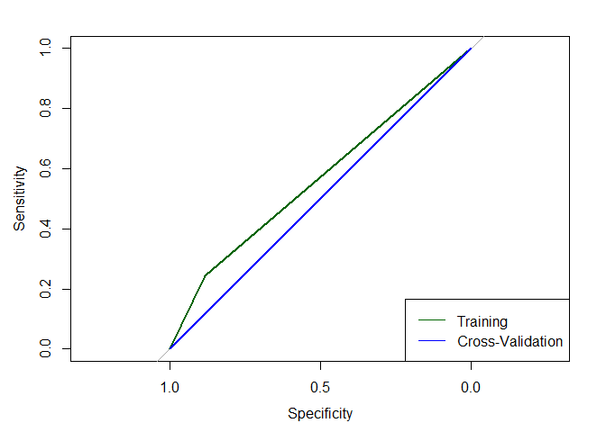

```r
#Adjusted Survival
lmerge_complete <- merge_map[complete.cases(merge_map[, c('cum_events', 'outcome2', 'q40inc', 'e_SES', 'edu', 'race', 'sex', 'life_cogA', 'a_cogR', 'income_bl', 'apoe')]),]
label(lmerge_complete$cum_events) <- "Cumulative Stressful Events"


cfit3 <- coxph(Surv(fu_year, time2, outcome2) ~ cum_events + q40inc + e_SES + edu + race + sex + life_cogA + a_cogR + income_bl + apoe, id = id, lmerge_complete)
cph.pred2 <- predict(cfit3, data = lmerge_complete, type = 'risk')
cph.pred2 <- case_when(cph.pred2 <0.5 ~ 0, cph.pred2 >= 0.5 ~ 1)

adjust_cox <- tbl_regression(cfit3, exponentiate = TRUE, include = c(cum_events, apoe))

#K-fold Cross Validation
N = nrow(lmerge_complete)
K = 10
set.seed(1234)
s = sample(1:K, size = N, replace = T)
pred.outputs.cph2 <- vector(mode = "numeric", length = N)
obs.outputs2 <- vector(mode = "numeric", length = N)
offset <- 0
for (i in 1:K) {
  train <- filter(lmerge_complete, s !=i)
  test <- filter(lmerge_complete, s == i)
  obs.outputs2[1:length(s[s == i]) + offset] <- test$outcome2

  cfit4 <- coxph(Surv(fu_year, time2, outcome2) ~ cum_events + q40inc + e_SES + edu + race + sex + life_cogA + a_cogR + income_bl + apoe, id = id, lmerge_complete)
  cph.pred.curr2 <- predict(cfit4, data = test, type = 'risk')
  pred.outputs.cph2[1:length(s[s == i]) + offset] <- cph.pred.curr2
  pred.outputs.cph2 <- case_when(pred.outputs.cph2 <0.5 ~ 0, pred.outputs.cph2 >= 0.5 ~ 1)

  offset <- offset + length(s[s == i])
}

adjust_cox_cv <- tbl_regression(cfit4, exponentiate = TRUE, include = c(cum_events, apoe))

#roc curves together
plot.roc(cph.pred2, lmerge_complete$outcome2, col = 'darkgreen')
plot.roc(obs.outputs2, pred.outputs.cph2, col = 'blue', add = TRUE)
legend("bottomright", legend = c("Training", "Cross-Validation"), col = c("darkgreen", "blue"), lwd = 1)
```

```r
tbl_merge(list(Unadjust_cox, unadjust_cox_CV, adjust_cox, adjust_cox_cv), tab_spanner = (paste0(c("Unadjusted Model", "Unadjusted Cross Validation", "Adjusted Model*", "Adjusted Cross Validation*")))) %>%
  as_gt() %>%
  gt::tab_source_note(str_glue("*Adjusted for Income at age 40, early childhood SES, Education, Race, Sex, Lifetime Cognitive Activity, Adult Cognitive Resources, Income at Baseline, and ApoE Genotype"))
```

| **Characteristic** | Unadjusted Model **HR**<sup>1</sup> | Unadjusted Model **95% CI**<sup>1</sup> | Unadjusted Model **p-value** | Unadjusted Cross Validation **HR**<sup>1</sup> | Unadjusted Cross Validation **95% CI**<sup>1</sup> | Unadjusted Cross Validation **p-value** | Adjusted Model* **HR**<sup>1</sup> | Adjusted Model* **95% CI**<sup>1</sup> | Adjusted Model* **p-value** | Adjusted Cross Validation* **HR**<sup>1</sup> | Adjusted Cross Validation* **95% CI**<sup>1</sup> | Adjusted Cross Validation* **p-value** |
| --- | --- | --- | --- | --- | --- | --- | --- | --- | --- | --- | --- | --- |
| Cumulative Stressful Events | 0.92 | 0.90, 0.95 | <0.001 | 0.92 | 0.90, 0.95 | <0.001 | 0.96 | 0.93, 0.99 | 0.003 | 0.96 | 0.93, 0.99 | 0.003 |
| ApoE Genotype |  |  |  |  |  |  |  |  |  |  |  |  |
| E2E2 |  |  |  |  |  |  | — | — |  | — | — |  |
| E2E3 |  |  |  |  |  |  | 0.83 | 0.42, 1.67 | 0.6 | 0.83 | 0.42, 1.67 | 0.6 |
| E2E4 |  |  |  |  |  |  | 0.85 | 0.36, 2.01 | 0.7 | 0.85 | 0.36, 2.01 | 0.7 |
| E3E3 |  |  |  |  |  |  | 1.03 | 0.53, 2.00 | >0.9 | 1.03 | 0.53, 2.00 | >0.9 |
| E3E4 |  |  |  |  |  |  | 1.48 | 0.75, 2.91 | 0.3 | 1.48 | 0.75, 2.91 | 0.3 |
| E4E4 |  |  |  |  |  |  | 2.33 | 1.06, 5.13 | 0.035 | 2.33 | 1.06, 5.13 | 0.035 |

*Adjusted for Income at age 40, early childhood SES, Education, Race, Sex, Lifetime Cognitive Activity, Adult Cognitive Resources, Income at Baseline, and ApoE Genotype  
<sup>1</sup> HR = Hazard Ratio, CI = Confidence Interval

For the adjusted model the AUC also appears to be lower for the cross-validation set and is close to 0.5, indicating poor predictive ability. Across all models, increasing cumulative stressful life events is associated with lower hazard of experiencing cognitive impairment during the follow up time.

# 5 Conclusions

This analysis provided evidence against both hypotheses that childhood adversity and stressful life events would increase odds or hazard of cognitive impairment. In fact, we observe evidence that these experiences decrease the risk of cognitive impairment. This could be due to a number of factors including misclassification, residual confounding, and misspecification of models. It is possible that participants who are better equipped to cope with adversity and stress are more likely to report these experiences, leading to misclassification and potential confounding by presence of coping strategies. Additionally, while Cox Proportional Hazards models are helpful in analyzing longitudinal data with time dependent covariates, models which account for competing risks may be more appropriate to use in this dataset, especially given the advanced age of participants. Future projects can assess risk of cognitive impairment accounting for coping strategies and competing risks.

# 6 References

> 1. Matthews KA, Xu W, Gaglioti AH, et al. Racial and ethnic estimates of alzheimer’s disease and related dementias in the united states (2015-2060) in adults aged ≥65 years. Alzheimers Dement. 2019;15(1):17-24. Accessed Oct 6, 2022. doi: 10.1016/j.jalz.2018.06.3063.
> 2. Rajan KB, Weuve J, Barnes LL, McAninch EA, Wilson RS, Evans DA. Population estimate of people with clinical Alzheimer’s disease and mild cognitive impairment in the United States (2020-2060). Alzheimers Dement. 2021;17(12):1966-1975. doi:10.1002/alz.12362
> 3. Wimo A, Guerchet M, Ali G, et al. The worldwide costs of dementia 2015 and comparisons with 2010. Alzheimers Dement. 2017;13(1):1-7. Accessed Oct 6, 2022. doi: 10.1016/j.jalz.2016.07.150.
> 4. Brookmeyer R, Johnson E, Ziegler-Graham K, Arrighi HM. Forecasting the global burden of alzheimer’s disease. Alzheimers Dement. 2007;3(3):186-191. Accessed Oct 6, 2022. doi: 10.1016/j.jalz.2007.04.381.
> 5. Schneider JA, Aggarwal NT, Barnes L, Boyle P, Bennett DA. The neuropathology of older persons with and without dementia from community versus clinic cohorts. J Alzheimers Dis. 2009;18(3):691-701. Accessed Oct 5, 2022. doi: 10.3233/JAD-2009-1227.
> 6. Stern Y. Cognitive reserve. Neuropsychologia. 2009;47(10):2015-2028. Accessed Oct 6, 2022. doi: 10.1016/j.neuropsychologia.2009.03.004.
> 7. Fay TB, Yeates KO, Taylor HG, et al. Cognitive reserve as a moderator of postconcussive symptoms in children with complicated and uncomplicated mild traumatic brain injury. J Int Neuropsychol Soc. 2010;16(1):94-105. Accessed Oct 6, 2022. doi: 10.1017/S1355617709991007.
> 8. Poletti M, Emre M, Bonuccelli U. Mild cognitive impairment and cognitive reserve in parkinson’s disease. Parkinsonism Relat Disord. 2011;17(8):579-586. Accessed Oct 6, 2022. doi: 10.1016/j.parkreldis.2011.03.013.
> 9. Aiello Bowles EJ, Crane PK, Walker RL, et al. Cognitive Resilience to Alzheimer’s Disease Pathology in the Human Brain. J Alzheimers Dis. 2019;68(3):1071-1083. doi:10.3233/JAD-180942
> 10. Wilson RS, Scherr PA, Schneider JA, Tang Y, Bennett DA. Relation of cognitive activity to risk of developing alzheimer disease. Neurology. 2007;69(20):1911-1920. Accessed Oct 5, 2022. doi: 10.1212/01.wnl.0000271087.67782.cb.
> 11. Bennett DA, Wilson RS, Schneider JA, et al. Education modifies the relation of AD pathology to level of cognitive function in older persons. Neurology. 2003;60(12):1909-1915. Accessed Oct 5, 2022. doi: 10.1212/01.wnl.0000069923.64550.9f.
> 12. Mejía S, Giraldo M, Pineda D, Ardila A, Lopera F. Nongenetic factors as modifiers of the age of onset of familial alzheimer’s disease. Int Psychogeriatr. 2003;15(4):337-349. Accessed Oct 5, 2022. doi: 10.1017/s1041610203009591.
> 13. Bale TL, Baram TZ, Brown AS, et al. Early life programming and neurodevelopmental disorders. Biol Psychiatry. 2010;68(4):314-319. Accessed Oct 5, 2022. doi: 10.1016/j.biopsych.2010.05.028.
> 14. Sierksma ASR, Prickaerts J, Chouliaras L, et al. Behavioral and neurobiological effects of prenatal stress exposure in male and female APPswe/PS1dE9 mice. Neurobiol Aging. 2013;34(1):319-337. Accessed Oct 5, 2022. doi: 10.1016/j.neurobiolaging.2012.05.012.